# I did my Homework using Jupyter Notebook

1. Exercise 1
2. Exercise 2
3. Exercise 3
4. Exercise 4
5. Exercise 5
6. Exercise 6
7. Exercise 7
8. Exercise 8
9. Exercise 9
10. Exercise 10
11. Exercise 11
12. Exercise 12
13. Exercise 13
14. Exercise 14
15. Exercise 15
16. Exercise 16
17. Exercise 17
18. Exercise 18
19. Exercise 19
20. Exercise 20
21. Exercise 21
22. Exercise 22
23. Exercise 23

This file shows some of the solutions for exercises in my biostatistics book using the data from the table below (displaying first few rows):

```python
import pandas as pd

# Upload Excel data file
uploaded_file = './01 - Body Data.xlsx'  # Update with your file path

# Read Excel file
df = pd.read_excel(uploaded_file)
```

```python
# Displaying the first rows
df.head()
```

|  | AGE | GENDER (1=M) | PULSE | SYSTOLIC | DIASTOLIC | HDL | LDL | WHITE | RED | PLATE | WEIGHT | HEIGHT | WAIST | ARM CIRC | BMI |
| --- | --- | --- | --- | --- | --- | --- | --- | --- | --- | --- | --- | --- | --- | --- | --- |
| 0 | 43 | 0 | 80 | 100 | 70 | 73 | 68 | 8.7 | 4.80 | 319 | 98.6 | 172.0 | 120.4 | 40.7 | 33.3 |
| 1 | 57 | 1 | 84 | 112 | 70 | 35 | 116 | 4.9 | 4.73 | 187 | 96.9 | 186.0 | 107.8 | 37.0 | 28.0 |
| 2 | 38 | 0 | 94 | 134 | 94 | 36 | 223 | 6.9 | 4.47 | 297 | 108.2 | 154.4 | 120.3 | 44.3 | 45.4 |
| 3 | 80 | 1 | 74 | 126 | 64 | 37 | 83 | 7.5 | 4.32 | 170 | 73.1 | 160.5 | 97.2 | 30.3 | 28.4 |
| 4 | 34 | 1 | 50 | 114 | 68 | 50 | 104 | 6.1 | 4.95 | 140 | 83.1 | 179.0 | 95.1 | 34.0 | 25.9 |

### Describing the data

```python
df.describe()
```

|  | AGE | GENDER (1=M) | PULSE | SYSTOLIC | DIASTOLIC | HDL | LDL | WHITE | RED | PLATE | WEIGHT | HEIGHT | WAIST | ARM CIRC | BMI |
| --- | --- | --- | --- | --- | --- | --- | --- | --- | --- | --- | --- | --- | --- | --- | --- |
| count | 300.000000 | 300.000000 | 300.000000 | 300.000000 | 300.000000 | 300.000000 | 300.000000 | 300.000000 | 300.000000 | 300.000000 | 300.000000 | 300.000000 | 300.000000 | 300.000000 | 300.000000 |
| mean | 47.040000 | 0.510000 | 71.766667 | 122.960000 | 70.753333 | 53.663333 | 113.713333 | 6.542333 | 4.537767 | 239.373333 | 81.656333 | 168.030333 | 99.178333 | 33.078333 | 28.912333 |
| std | 18.269583 | 0.500735 | 12.128033 | 15.851687 | 11.616179 | 15.438409 | 35.188995 | 1.910009 | 0.484610 | 64.227496 | 19.675182 | 9.579338 | 16.477337 | 4.815037 | 6.746703 |
| min | 18.000000 | 0.000000 | 36.000000 | 88.000000 | 40.000000 | 26.000000 | 39.000000 | 2.700000 | 3.390000 | 75.000000 | 39.000000 | 134.500000 | 64.400000 | 20.500000 | 15.900000 |
| 25% | 31.000000 | 0.000000 | 64.000000 | 112.000000 | 64.000000 | 43.000000 | 85.000000 | 5.200000 | 4.197500 | 198.000000 | 67.075000 | 161.575000 | 87.875000 | 29.475000 | 24.500000 |
| 50% | 46.000000 | 1.000000 | 72.000000 | 121.000000 | 70.000000 | 52.000000 | 113.000000 | 6.200000 | 4.490000 | 232.000000 | 80.500000 | 168.350000 | 96.950000 | 33.050000 | 28.000000 |
| 75% | 62.000000 | 1.000000 | 80.000000 | 132.000000 | 78.000000 | 62.000000 | 137.250000 | 7.825000 | 4.882500 | 263.500000 | 92.800000 | 174.625000 | 109.100000 | 36.325000 | 31.975000 |
| max | 80.000000 | 1.000000 | 104.000000 | 186.000000 | 102.000000 | 138.000000 | 251.000000 | 14.300000 | 6.340000 | 646.000000 | 150.400000 | 193.300000 | 170.500000 | 46.600000 | 59.000000 |

### Exercise 1

Use the pulse rates (beats per minute) of males. Begin with a lower class limit of 40 and use a class width of 10. Do the pulse rates of males appear to have a normal distribution?

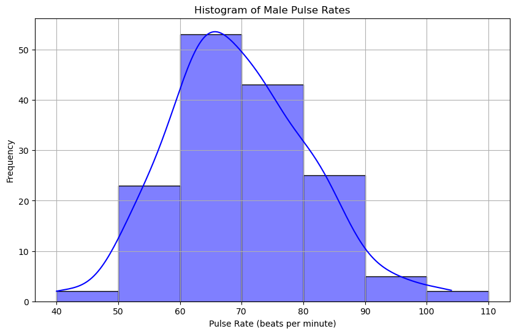

```python
import warnings
warnings.filterwarnings('ignore', category=FutureWarning)

import matplotlib.pyplot as plt
import seaborn as sns
import numpy as np

# Filtering pulse rates for males
pulse_rates_males = df[df['GENDER (1=M)'] == 1]['PULSE']

# Define class intervals
class_width = 10
lower_class_limit = 40
upper_class_limit = pulse_rates_males.max() + class_width - (pulse_rates_males.max() % class_width)

bins = list(range(lower_class_limit, upper_class_limit + class_width, class_width))

# Histogram
plt.figure(figsize=(10, 6))
sns.histplot(pulse_rates_males, bins=bins, kde=True, color='blue', edgecolor='black')
plt.title('Histogram of Male Pulse Rates')
plt.xlabel('Pulse Rate (beats per minute)')
plt.ylabel('Frequency')
plt.grid(True)
plt.show()
```

### Exercise 2

Use the pulse rates (beats per minute) of females. Begin with a lower class limit of 30 and use a class width of 10. Do the pulse rates of females appear to have a normal distribution?

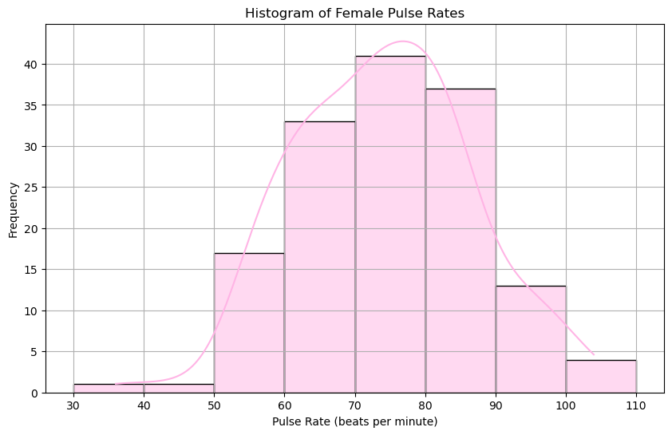

```python
# Filtering pulse rates for females
pulse_rates_females = df[df['GENDER (1=M)'] == 0]['PULSE']

# Define class intervals
class_width = 10
lower_class_limit = 30
upper_class_limit = pulse_rates_females.max() + class_width - (pulse_rates_females.max() % class_width)

bins = list(range(lower_class_limit, upper_class_limit + class_width, class_width))

# Histogram
plt.figure(figsize=(10, 6))
sns.histplot(pulse_rates_females, bins=bins, kde=True, color='#ffb4e5', edgecolor='black')
plt.title('Histogram of Female Pulse Rates')
plt.xlabel('Pulse Rate (beats per minute)')
plt.ylabel('Frequency')
plt.grid(True)
plt.show()
```

The bell shape does not appear symmetric, not describing normally-distributed data.

### Exercise 3

Use the red blood cell counts (million cells/µL) for males. Begin with a lower class limit of 3.00 and use a class width of 0.50.

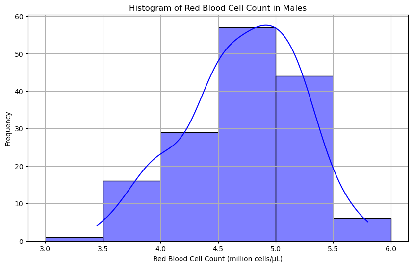

```python
import numpy as np

# Filtering red blood cell counts for males
red_counts_males = df[df['GENDER (1=M)'] == 1]['RED']

# Define class intervals
class_width = 0.50
lower_class_limit = 3.00
upper_class_limit = red_counts_males.max() + class_width - (red_counts_males.max() % class_width)

bins = np.arange(lower_class_limit, upper_class_limit + class_width, class_width)

# Histogram
plt.figure(figsize=(10, 6))
sns.histplot(red_counts_males, bins=bins, kde=True, color='blue', edgecolor='black')
plt.title('Histogram of Red Blood Cell Count in Males')
plt.xlabel('Red Blood Cell Count (million cells/µL)')
plt.ylabel('Frequency')
plt.grid(True)
plt.show()
```

### Exercise 4

Show a dotplot of the pulse rates (beats per minute) of males. Is there a pulse rate that appears to be an outlier? What is its value?

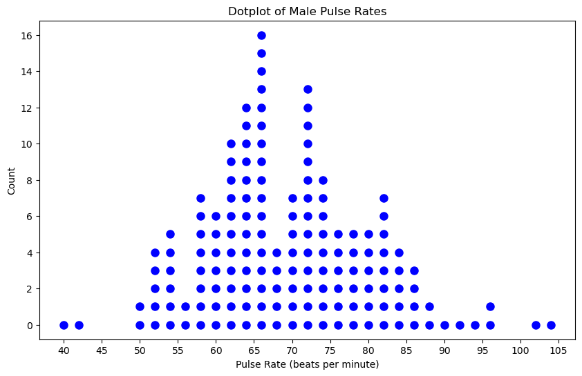

```python
# Pulse rates for males
pulse_rates_males = df[df['GENDER (1=M)'] == 1]['PULSE']

# Create the dot plot
plt.figure(figsize=(10, 6))
unique_pulse_rates, counts = np.unique(pulse_rates_males, return_counts=True)

for pulse_rate, count in zip(unique_pulse_rates, counts):
    plt.plot([pulse_rate] * count, range(count), 'bo', markersize=8)

plt.title('Dotplot of Male Pulse Rates')
plt.xlabel('Pulse Rate (beats per minute)')
plt.ylabel('Count')
plt.xticks(np.arange(min(unique_pulse_rates), max(unique_pulse_rates) + 5, 5))
plt.grid(False)
plt.show()
```

### Exercise 5

Based on ages, do the males and females in Data Set 1 appear to be similar?

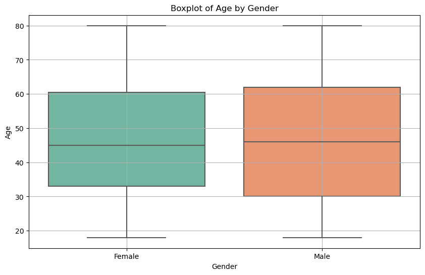

Summary Statistics: Age by Gender

|  | GENDER (1=M) | count | mean | std |
| --- | --- | --- | --- | --- |
| 0 | Female | 147 | 46.67 | 17.66 |
| 1 | Male | 153 | 47.40 | 18.88 |

Mann-Whitney U Test Results: Age by Gender

|  | Statistic | Value |
| --- | --- | --- |
| 0 | Mann-Whitney U Statistic | 11418.0000 |
| 1 | P-value | 0.8188 |

```python
age = df['AGE']
gender = df['GENDER (1=M)']

# Create a boxplot
plt.figure(figsize=(10, 6))
sns.boxplot(x=gender, y=age, palette='Set2')
plt.title('Boxplot of Age by Gender')
plt.xlabel('Gender')
plt.ylabel('Age')
plt.xticks([0, 1], ['Female', 'Male'])
plt.grid(True)
plt.show()

# Mann-Whitney U test
age_male = df[df['GENDER (1=M)'] == 1]['AGE']
age_female = df[df['GENDER (1=M)'] == 0]['AGE']
u_statistic, p_value = stats.mannwhitneyu(age_male, age_female)

results_df = pd.DataFrame({
    'Statistic': ['Mann-Whitney U Statistic', 'P-value'],
    'Value': [u_statistic, p_value]
})

# Tables
styled_table = results_df.style.format(precision=4).set_caption('Mann-Whitney U Test Results:<br> Age by Gender')

summary_df = df.groupby('GENDER (1=M)').agg(
    count=('AGE', 'count'),
    mean=('AGE', 'mean'),
    std=('AGE', 'std')
).reset_index()

summary_df['GENDER (1=M)'] = summary_df['GENDER (1=M)'].map({0: 'Female', 1: 'Male'})
summary_table = summary_df.style.format({'mean': '{:.2f}', 'std': '{:.2f}'}).set_caption('Summary Statistics:<br> Age by Gender')

# Displaying the tables
display_html(f"""
<div style="display: flex; justify-content: space-evenly;">
    <div style="flex: 1; padding: 10px;">{summary_table.to_html()}</div>
    <div style="flex: 1; padding: 10px;">{styled_table.to_html()}</div>
</div>
""", raw=True)
```

### Exercise 6

Is there a difference between the body mass index (BMI) values for men and for women?

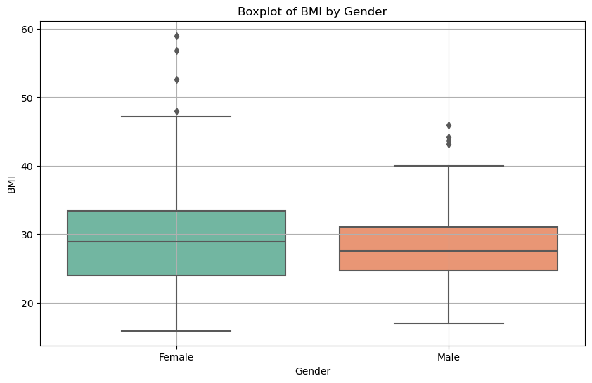

Summary Statistics: BMI by Gender

|  | GENDER (1=M) | count | mean | std |
| --- | --- | --- | --- | --- |
| 0 | Female | 147 | 29.69 | 7.90 |
| 1 | Male | 153 | 28.16 | 5.33 |

Mann-Whitney U Test Results: BMI by Gender

|  | Statistic | Value |
| --- | --- | --- |
| 0 | Mann-Whitney U Statistic | 10481.0000 |
| 1 | P-value | 0.3091 |

```python
bmi = df['BMI']
gender = df['GENDER (1=M)']

# Boxplot
plt.figure(figsize=(10, 6))
sns.boxplot(x=gender, y=bmi, palette='Set2')
plt.title('Boxplot of BMI by Gender')
plt.xlabel('Gender')
plt.ylabel('BMI')
plt.xticks([0, 1], ['Female', 'Male'])
plt.grid(True)
plt.show()

# Mann-Whitney U test
bmi_male = df[df['GENDER (1=M)'] == 1]['BMI']
bmi_female = df[df['GENDER (1=M)'] == 0]['BMI']
u_statistic, p_value = stats.mannwhitneyu(bmi_male, bmi_female)

# Results
results_df = pd.DataFrame({
    'Statistic': ['Mann-Whitney U Statistic', 'P-value'],
    'Value': [u_statistic, p_value]
})


styled_table = results_df.style.format(precision=4).set_caption('Mann-Whitney U Test Results:<br> BMI by Gender')
summary_df = df.groupby('GENDER (1=M)').agg(
    count=('BMI', 'count'),
    mean=('BMI', 'mean'),
    std=('BMI', 'std')
).reset_index()


summary_df['GENDER (1=M)'] = summary_df['GENDER (1=M)'].map({0: 'Female', 1: 'Male'})

summary_table = summary_df.style.format({'mean': '{:.2f}', 'std': '{:.2f}'}).set_caption('Summary Statistics:<br> BMI by Gender')

display_html(f"""
<div style="display: flex; justify-content: space-evenly;">
    <div style="flex: 1; padding: 10px;">{summary_table.to_html()}</div>
    <div style="flex: 1; padding: 10px;">{styled_table.to_html()}</div>
</div>
""", raw=True)
```

The mean BMI for females is slightly higher than for males, the standard deviation is also higher: More variability in BMI values among females compared to males. The p-value is greater than 0.05, we fail to reject the null hypothesis - There is no statistically significant difference in the BMI distributions between men and women in this sample.

### Exercise 7

Use the high-density lipoprotein (HDL) cholesterol measurements (mg>dL) from the 300 subjects included in Data Set 1 “Body Data”. Identify the highest value. Does it appear to be an outlier? Do the mean and median change much when that highest value is deleted?

```python
hdl_measurements = df['HDL'].tolist()

# Highest value
max_value = max(hdl_measurements)

# Is the max value an outlier?
Q1 = df['HDL'].quantile(0.25)
Q3 = df['HDL'].quantile(0.75)
IQR = Q3 - Q1
upper_bound = Q3 + 1.5 * IQR

is_outlier = max_value > upper_bound

# Calculate mean and median
mean_before = df['HDL'].mean()
median_before = df['HDL'].median()

# Calculate mean and median without the highest value
hdl_measurements_without_max = [x for x in hdl_measurements if x != max_value]
mean_after = pd.Series(hdl_measurements_without_max).mean()
median_after = pd.Series(hdl_measurements_without_max).median()

# Print results
print(f"Highest value of HDL cholesterol: {max_value}")
print(f"Is the highest value an outlier? {is_outlier}")
print(f"Mean before removing the highest value: {mean_before}")
print(f"Median before removing the highest value: {median_before}")
print(f"Mean after removing the highest value: {mean_after}")
print(f"Median after removing the highest value: {median_after}")
```

```
Highest value of HDL cholesterol: 138
Is the highest value an outlier? True
Mean before removing the highest value: 53.663333333333334
Median before removing the highest value: 52.0
Mean after removing the highest value: 53.381270903010034
Median after removing the highest value: 52.0
```

### Exercise 8

Repeat the preceding exercise using the low-density lipoprotein (LDL) measurements (mg>dL).

```python
ldl_measurements = df['LDL'].tolist()

# Highest value
max_value = max(ldl_measurements)

# Is the highest value an outlier?
Q1 = df['LDL'].quantile(0.25)
Q3 = df['LDL'].quantile(0.75)
IQR = Q3 - Q1
upper_bound = Q3 + 1.5 * IQR

is_outlier = max_value > upper_bound

# Calculate mean and median
mean_before = df['LDL'].mean()
median_before = df['LDL'].median()

# Calculate mean and median without the highest value
hdl_measurements_without_max = [x for x in hdl_measurements if x != max_value]
mean_after = pd.Series(hdl_measurements_without_max).mean()
median_after = pd.Series(hdl_measurements_without_max).median()

# Print results
print(f"Highest value of LDL cholesterol: {max_value}")
print(f"Is the highest value an outlier? {is_outlier}")
print(f"Mean before removing the highest value: {mean_before}")
print(f"Median before removing the highest value: {median_before}")
print(f"Mean after removing the highest value: {mean_after}")
print(f"Median after removing the highest value: {median_after}")
```

```
Highest value of LDL cholesterol: 251
Is the highest value an outlier? True
Mean before removing the highest value: 113.71333333333334
Median before removing the highest value: 113.0
Mean after removing the highest value: 53.663333333333334
Median after removing the highest value: 52.0
```

### Exercise 9

Based on Data Set 1 “Body Data”, males have red blood cell counts with a mean of 4.719 and a standard deviation of 0.490, while females have red blood cell counts with a mean of 4.349 and a standard deviation of 0.402. Who has the higher count relative to the sample from which it came: a male with a count of 5.58 or a female with a count of 5.23? Explain.ain.

```python
# Given data
mean_male = 4.719
std_dev_male = 0.490
red_blood_cell_count_male = 5.58

mean_female = 4.349
std_dev_female = 0.402
red_blood_cell_count_female = 5.23

# Calculate z-scores
z_score_male = (red_blood_cell_count_male - mean_male) / std_dev_male
z_score_female = (red_blood_cell_count_female - mean_female) / std_dev_female

# Compare z-scores
if abs(z_score_male) > abs(z_score_female):
    print("The male with a count of 5.58 has a higher count relative to their sample.")
elif abs(z_score_female) > abs(z_score_male):
    print("The female with a count of 5.23 has a higher count relative to their sample.")
else:
    print("Both have counts that are equally distant from their respective sample means.")

print(f"Z-score for male: {z_score_male:.2f}")
print(f"Z-score for female: {z_score_female:.2f}")
```

```
The female with a count of 5.23 has a higher count relative to their sample.
Z-score for male: 1.76
Z-score for female: 2.19
```

### Exercise 10

Diastolic Blood Pressure of Males Refer to Data Set 1 in Appendix B and use the diastolic blood pressures of males.

1. Find the mean and standard deviation, and verify that the data have a distribution that is roughly normal. Round the results using three decimal places.
2. Treating the unrounded values of the mean and standard deviation as parameters, and assuming that male diastolic blood pressures are normally distributed, find diastolic blood pressures separating the lowest 2.5% and the highest 2.5%. These values could be helpful when physicians try to determine whether diastolic blood pressures are significantly low or significantly high.

**Part (a): Calculate mean and standard deviation**

```
Mean (rounded to three decimal places): 71.32
Standard Deviation (rounded to three decimal places): 11.994
```

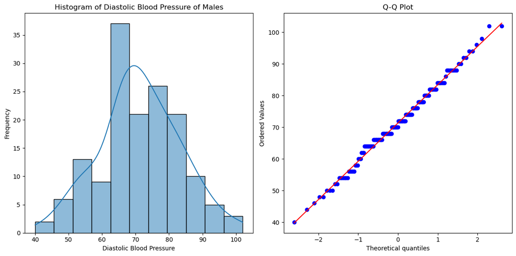

**Part (b): Calculate the 2.5th and 97.5th percentiles**

```
Diastolic blood pressure separating the lowest 2.5%: 47.813
Diastolic blood pressure separating the highest 2.5%: 94.828
```

```python
from IPython.display import display, Markdown

diastolic_bp_males = df[df['GENDER (1=M)'] == 1]['DIASTOLIC']

display(Markdown("**Part (a): Calculate mean and standard deviation**"))
mean_bp = diastolic_bp_males.mean()
std_bp = diastolic_bp_males.std()

mean_bp_rounded = round(mean_bp, 3)
std_bp_rounded = round(std_bp, 3)

# Results
print(f"Mean (rounded to three decimal places): {mean_bp_rounded}")
print(f"Standard Deviation (rounded to three decimal places): {std_bp_rounded}")

# Plots
plt.figure(figsize=(12, 6))

plt.subplot(1, 2, 1)
sns.histplot(diastolic_bp_males, kde=True)
plt.title('Histogram of Diastolic Blood Pressure of Males')
plt.xlabel('Diastolic Blood Pressure')
plt.ylabel('Frequency')

plt.subplot(1, 2, 2)
stats.probplot(diastolic_bp_males, dist="norm", plot=plt)
plt.title('Q-Q Plot')
plt.tight_layout()
plt.show()

display(Markdown("**Part (b): Calculate the 2.5th and 97.5th percentiles**"))
z_025 = stats.norm.ppf(0.025)
z_975 = stats.norm.ppf(0.975)

# Convert z-scores to diastolic blood pressures
bp_025 = mean_bp + z_025 * std_bp
bp_975 = mean_bp + z_975 * std_bp

# Results
print(f"Diastolic blood pressure separating the lowest 2.5%: {bp_025:.3f}")
print(f"Diastolic blood pressure separating the highest 2.5%: {bp_975:.3f}")
```

### Exercise 11

Repeat the preceding exercise using females instead of males.

**Part (a): Calculate mean and standard deviation**

```
Mean (rounded to three decimal places): 70.163
Standard Deviation (rounded to three decimal places): 11.22
```

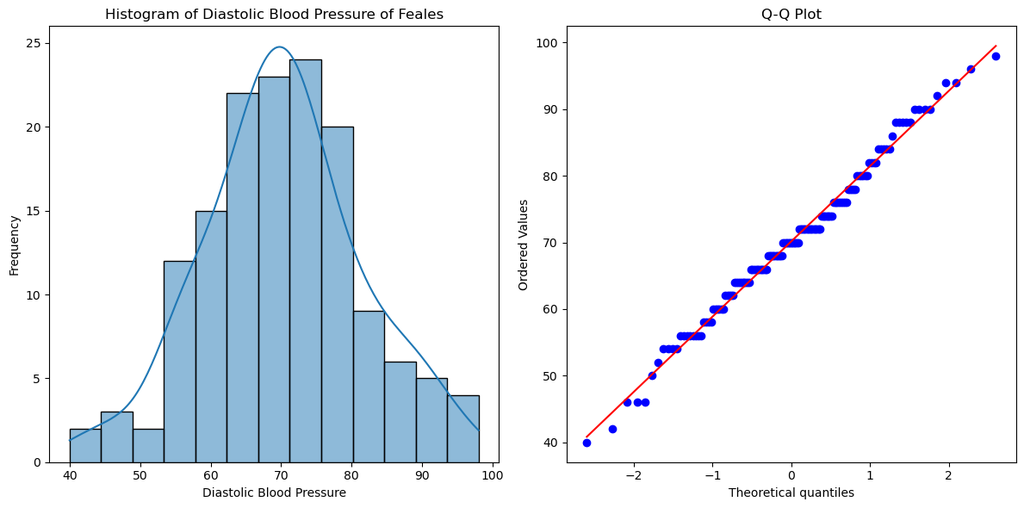

**Part (b): Calculate the 2.5th and 97.5th percentiles**

```
Diastolic blood pressure separating the lowest 2.5%: 48.172
Diastolic blood pressure separating the highest 2.5%: 92.154
```

```python
diastolic_bp_females = df[df['GENDER (1=M)'] == 0]['DIASTOLIC']

display(Markdown("**Part (a): Calculate mean and standard deviation**"))
mean_bp = diastolic_bp_females.mean()
std_bp = diastolic_bp_females.std()

mean_bp_rounded = round(mean_bp, 3)
std_bp_rounded = round(std_bp, 3)

# Results
print(f"Mean (rounded to three decimal places): {mean_bp_rounded}")
print(f"Standard Deviation (rounded to three decimal places): {std_bp_rounded}")

# Plots
plt.figure(figsize=(12, 6))

plt.subplot(1, 2, 1)
sns.histplot(diastolic_bp_females, kde=True)
plt.title('Histogram of Diastolic Blood Pressure of Feales')
plt.xlabel('Diastolic Blood Pressure')
plt.ylabel('Frequency')

plt.subplot(1, 2, 2)
stats.probplot(diastolic_bp_females, dist="norm", plot=plt)
plt.title('Q-Q Plot')

plt.tight_layout()
plt.show()

display(Markdown("**Part (b): Calculate the 2.5th and 97.5th percentiles**"))
z_025 = stats.norm.ppf(0.025)
z_975 = stats.norm.ppf(0.975)

bp_025 = mean_bp + z_025 * std_bp
bp_975 = mean_bp + z_975 * std_bp

# Results
print(f"Diastolic blood pressure separating the lowest 2.5%: {bp_025:.3f}")
print(f"Diastolic blood pressure separating the highest 2.5%: {bp_975:.3f}")
```

### Exercise 12

In Exercises 1-2, generate a normal quantile plot. Then determine whether the data come from a normally distributed population.

1. White blood cell counts of females from Data Set 1 “Body Data”.
2. Red blood cell counts of females from Data Set 1 “Body Data”.

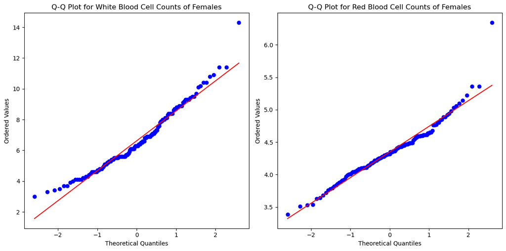

```python
wbc_females = df[df['GENDER (1=M)'] == 0]['WHITE']
rbc_females = df[df['GENDER (1=M)'] == 0]['RED']

# Generate Q-Q plots
plt.figure(figsize=(12, 6))

# Q-Q Plot for White Blood Cell Counts
plt.subplot(1, 2, 1)
stats.probplot(wbc_females, dist="norm", plot=plt)
plt.title('Q-Q Plot for White Blood Cell Counts of Females')
plt.xlabel('Theoretical Quantiles')
plt.ylabel('Ordered Values')

# Q-Q Plot for Red Blood Cell Counts
plt.subplot(1, 2, 2)
stats.probplot(rbc_females, dist="norm", plot=plt)
plt.title('Q-Q Plot for Red Blood Cell Counts of Females')
plt.xlabel('Theoretical Quantiles')
plt.ylabel('Ordered Values')

plt.tight_layout()
plt.show()
```

By visually inspecting the Q-Q plots, we can determine if the data are normally distributed. If the points in the Q-Q plot lie approximately along the reference line, the data can be considered to come from a normal distribution.

### Exercise 13

Assume that women have diastolic blood pressure measures that are normally distributed with a mean of 70.2 mm Hg and a standard deviation of 11.2 mm H.:

```python
import scipy.stats as stats

# Given data
mean_bp = 70.2
std_bp = 11.2

# Exercise 1
prob_below_80 = stats.norm.cdf(80, mean_bp, std_bp)
print(f"1. Probability that a randomly selected woman has a diastolic blood pressure level below 80 mm Hg: {prob_below_80:.4f}")

# Exercise 2
prob_between_60_and_80 = stats.norm.cdf(80, mean_bp, std_bp) - stats.norm.cdf(60, mean_bp, std_bp)
print(f"2. Probability that a randomly selected woman has a diastolic blood pressure level between 60 mm Hg and 80 mm Hg: {prob_between_60_and_80:.4f}")

# Exercise 3
p90 = stats.norm.ppf(0.90, mean_bp, std_bp)
print(f"3. The 90th percentile for the diastolic blood pressure levels of women (P90): {p90:.4f}")

# Exercise 4
sample_size = 16
std_error = std_bp / (sample_size ** 0.5)
prob_mean_less_than_75 = stats.norm.cdf(75, mean_bp, std_error)
print(f"4. Probability that the mean diastolic blood pressure of 16 women is less than 75 mm Hg: {prob_mean_less_than_75:.4f}")
```

```
1. Probability that a randomly selected woman has a diastolic blood pressure level below 80 mm Hg: 0.8092
2. Probability that a randomly selected woman has a diastolic blood pressure level between 60 mm Hg and 80 mm Hg: 0.6280
3. The 90th percentile for the diastolic blood pressure levels of women (P90): 84.5534
4. Probability that the mean diastolic blood pressure of 16 women is less than 75 mm Hg: 0.9568
```

### Exercise 14

Refer to Data Set 1 “Body Data” and construct a 95% confidence interval estimate of the mean pulse rate of adult females; then do the same for adult males. Compare the results.

```python
pulse_females = df[df['GENDER (1=M)'] == 0]['PULSE']
pulse_males = df[df['GENDER (1=M)'] == 1]['PULSE']

# Calculate 95% confidence interval
def confidence_interval(data, confidence=0.95):
    n = len(data)
    mean = data.mean()
    std_err = stats.sem(data)
    h = std_err * stats.t.ppf((1 + confidence) / 2, n - 1)
    return mean, mean - h, mean + h

# Confidence intervals
mean_females, ci_lower_females, ci_upper_females = confidence_interval(pulse_females)
mean_males, ci_lower_males, ci_upper_males = confidence_interval(pulse_males)

# Results
print(f"Female Pulse Rate: mean = {mean_females:.2f}, 95% CI = ({ci_lower_females:.2f}, {ci_upper_females:.2f})")
print(f"Male Pulse Rate: mean = {mean_males:.2f}, 95% CI = ({ci_lower_males:.2f}, {ci_upper_males:.2f})")

# Compare results
if ci_lower_females > ci_upper_males:
    comparison = "The confidence intervals do not overlap. Female pulse rates are significantly higher than male pulse rates."
elif ci_upper_females < ci_lower_males:
    comparison = "The confidence intervals do not overlap. Male pulse rates are significantly higher than female pulse rates."
else:
    comparison = "The confidence intervals overlap. There is no significant difference between female and male pulse rates."

print(comparison)
```

```
Female Pulse Rate: mean = 74.04, 95% CI = (72.00, 76.09)
Male Pulse Rate: mean = 69.58, 95% CI = (67.77, 71.39)
The confidence intervals do not overlap. Female pulse rates are significantly higher than male pulse rates.
```

### Exercise 15

Data Set 1 “Body Data” includes weights of 153 randomly selected adult males, and those weights have a standard deviation of 17.65 kg. Because it is reasonable to assume that weights of male medical students have less variation than weights of the population of adult males, we can be conservative by letting s = 17.65 kg. How many male medical students must be weighed in order to estimate the mean weight of all male medical students? Assume that we want 90% confidence that the sample mean is within 1.5 kg of the population mean. Does it seem reasonable to assume that weights of male medical students have less variation than weights of the population of adult males?

```python
import scipy.stats as stats

# Given values
sigma = 17.65
E = 1.5
confidence_level = 0.90

# (Z_alpha/2) for 90% confidence level
alpha = 1 - confidence_level
z_alpha_over_2 = stats.norm.ppf(1 - alpha / 2)

# Required sample size
n = (z_alpha_over_2 * sigma / E) ** 2
n = int(np.ceil(n))

print(f"Required sample size: {n}")
```

```
Required sample size: 375
```

### Exercise 16

Use the pulse rates of adult females and males listed in Data Set 1 “Body Data” to test the claim that the mean is less than 75 bpm. Use a 0.05 significance level.

```python
pulse_females = df[df['GENDER (1=M)'] == 0]['PULSE']
pulse_males = df[df['GENDER (1=M)'] == 1]['PULSE']

# Test for females
t_stat_females, p_val_females = stats.ttest_1samp(pulse_females, 75)
p_val_females = p_val_females / 2  # One-tailed test

# Test for males
t_stat_males, p_val_males = stats.ttest_1samp(pulse_males, 75)
p_val_males = p_val_males / 2  # One-tailed test

# Results
display(Markdown("**Female Pulse Rate Test:**"))
print(f"T-statistic: {t_stat_females:.4f}, P-value: {p_val_females:.4f}")
if p_val_females < 0.05 and t_stat_females < 0:
    print("Reject the null hypothesis. The mean pulse rate of females is less than 75 bpm.")
else:
    print("Fail to reject the null hypothesis. There is not enough evidence to conclude that the mean pulse rate of females is less than 75 bpm.")

print("\n")
display(Markdown("**Male Pulse Rate Test:**"))
print(f"T-statistic: {t_stat_males:.4f}, P-value: {p_val_males:.4f}")
if p_val_males < 0.05 and t_stat_males < 0:
    print("Reject the null hypothesis. The mean pulse rate of males is less than 75 bpm.")
else:
    print("Fail to reject the null hypothesis. There is not enough evidence to conclude that the mean pulse rate of males is less than 75 bpm.")
```

**Female Pulse Rate Test:**

```
T-statistic: -0.9271, P-value: 0.1777
Fail to reject the null hypothesis. There is not enough evidence to conclude that the mean pulse rate of females is less than 75 bpm.
```

**Male Pulse Rate Test:**

```
T-statistic: -5.9145, P-value: 0.0000
Reject the null hypothesis. The mean pulse rate of males is less than 75 bpm.
```

### Exercise 17

Use the Waist and Arm Circumference data in Data Set 1 “Body Data” to test for correlation. Plot the data.

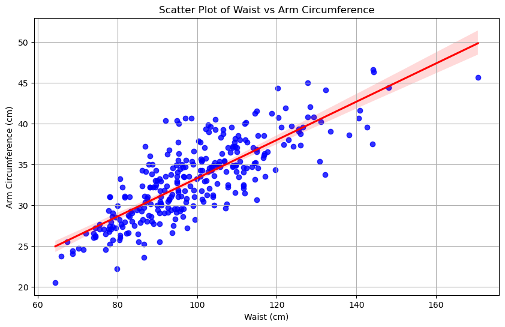

[output not shown]

Correlation: Waist and Arm Circumference

|  | Statistic | Value |
| --- | --- | --- |
| 0 | Correlation Coefficient | 0.8024 |
| 1 | P-value | 0.0000 |

```python
waist = df['WAIST']
arm_circumference = df['ARM CIRC']

# Calculatin Pearson correlation coefficient and p-value
correlation, p_value = stats.pearsonr(waist, arm_circumference)

results_df = pd.DataFrame({
    'Statistic': ['Correlation Coefficient', 'P-value'],
    'Value': [correlation, p_value]
})

styled_table = results_df.style.format(precision=4).set_caption('Correlation: Waist and Arm Circumference')


# Plot with a regression line
plt.figure(figsize=(10, 6))
sns.regplot(x=waist, y=arm_circumference, color='blue', line_kws={'color': 'red'})
plt.title('Scatter Plot of Waist vs Arm Circumference')
plt.xlabel('Waist (cm)')
plt.ylabel('Arm Circumference (cm)')
plt.grid(True)
plt.show()

if p_value < 0.05:
    print("Reject the null hypothesis. A correlation between Weight and Arm Circumference exists.")
else:
    print("Fail to reject the null hypothesis. There is not enough evidence to conclude that a correlation between Weight and Arm Circumference exists.")

styled_table
```

### Exercise 18

Do Men and Women Have the Same Mean Diastolic Blood Pressure? Refer to Data Set 1 “Body Data” and use a 0.05 significance level to test the claim that women and men have the same mean diastolic blood pressure.

```python
bp_females = df[df['GENDER (1=M)'] == 0]['DIASTOLIC']
bp_males = df[df['GENDER (1=M)'] == 1]['DIASTOLIC']

# Two-sample t-test
t_stat, p_val = stats.ttest_ind(bp_females, bp_males, equal_var=False)  # Assuming unequal variances

display(Markdown("**Two-Sample T-Test for Diastolic Blood Pressure:**"))
print(f"T-statistic: {t_stat:.4f}, P-value: {p_val:.4f}")

if p_val < 0.05:
    print("Reject the null hypothesis. There is a significant difference between the mean diastolic blood pressure of women and men.")
else:
    print("Fail to reject the null hypothesis. There is not enough evidence to conclude that the mean diastolic blood pressure of women and men are different.")
```

**Two-Sample T-Test for Diastolic Blood Pressure:**

```
T-statistic: -0.8632, P-value: 0.3887
Fail to reject the null hypothesis. There is not enough evidence to conclude that the mean diastolic blood pressure of women and men are different.
```

### Exercise 19

Refer to Data Set 1 “Body Data” and use the sex, height, and weight of the human subjects. Letting the response (y) variable represent sex (0 = female, 1 = male), use the variables of height and weight to find the multiple regression equation. Use the equation to find the probability that the subject is a male, given that the subject has a height of 170 cm and a weight of 90 kg.

```python
import pandas as pd
import statsmodels.api as sm

data = df[['GENDER (1=M)', 'HEIGHT', 'WEIGHT']].dropna()
data.columns = ['sex', 'height', 'weight']

# Add a constant to the predictor variables (intercept)
X = sm.add_constant(data[['height', 'weight']])
y = data['sex']

# Fit logistic regression model
model = sm.Logit(y, X).fit()

# Print the summary of the model
print(model.summary())

# Probability prediction
new_data = pd.DataFrame({'const': 1, 'height': 170, 'weight': 90}, index=[0])
probability = model.predict(new_data)[0]
print(f"Probability that the subject is male given a height of 170 cm and weight of 90 kg: {probability:.4f}")
```

```
Optimization terminated successfully.
         Current function value: 0.417631
         Iterations 7
                           Logit Regression Results
==============================================================================
Dep. Variable:                    sex   No. Observations:                  300
Model:                          Logit   Df Residuals:                      297
Method:                           MLE   Df Model:                            2
Date:                Mon, 08 Jul 2024   Pseudo R-squ.:                  0.3973
Time:                        15:09:00   Log-Likelihood:                -125.29
converged:                       True   LL-Null:                       -207.88
Covariance Type:            nonrobust   LLR p-value:                 1.348e-36
==============================================================================
                 coef    std err          z      P>|z|      [0.025      0.975]
------------------------------------------------------------------------------
const        -41.2369      4.749     -8.684      0.000     -50.544     -31.930
height         0.2500      0.029      8.493      0.000       0.192       0.308
weight        -0.0086      0.009     -0.950      0.342      -0.026       0.009
==============================================================================
Probability that the subject is male given a height of 170 cm and weight of 90 kg: 0.6200
```

### Exercise 20

Is there a linear correlation between HDL and LDL? What is the equation of the regression line? If the measurements are separated according to gender, do the results change very much? Write a brief report and include appropriate results from technology

```
Correlation coefficient: 0.0822, P-value: 0.1555
                            OLS Regression Results
==============================================================================
Dep. Variable:                    LDL   R-squared:                       0.007
Model:                            OLS   Adj. R-squared:                  0.003
Method:                 Least Squares   F-statistic:                     2.028
Date:                Mon, 08 Jul 2024   Prob (F-statistic):              0.155
Time:                        15:10:39   Log-Likelihood:                -1492.4
No. Observations:                 300   AIC:                             2989.
Df Residuals:                     298   BIC:                             2996.
Df Model:                           1
Covariance Type:            nonrobust
==============================================================================
                 coef    std err          t      P>|t|      [0.025      0.975]
------------------------------------------------------------------------------
const        103.6568      7.347     14.109      0.000      89.198     118.116
HDL            0.1874      0.132      1.424      0.155      -0.072       0.446
==============================================================================
Omnibus:                       11.380   Durbin-Watson:                   2.066
Prob(Omnibus):                  0.003   Jarque-Bera (JB):               11.683
Skew:                           0.477   Prob(JB):                      0.00290
Kurtosis:                       3.160   Cond. No.                         202.
==============================================================================

Notes:
[1] Standard Errors assume that the covariance matrix of the errors is correctly specified.
Regression line equation: LDL = 103.6568 + 0.1874 * HDL
```

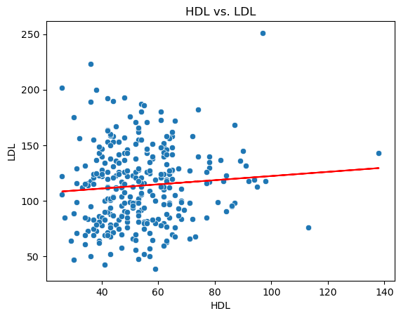

```
Gender: Female
Correlation coefficient: 0.0934, P-value: 0.2604
                            OLS Regression Results
==============================================================================
Dep. Variable:                    LDL   R-squared:                       0.009
Model:                            OLS   Adj. R-squared:                  0.002
Method:                 Least Squares   F-statistic:                     1.277
Date:                Mon, 08 Jul 2024   Prob (F-statistic):              0.260
Time:                        15:10:39   Log-Likelihood:                -720.80
No. Observations:                 147   AIC:                             1446.
Df Residuals:                     145   BIC:                             1452.
Df Model:                           1
Covariance Type:            nonrobust
==============================================================================
                 coef    std err          t      P>|t|      [0.025      0.975]
------------------------------------------------------------------------------
const        100.8794     10.929      9.230      0.000      79.278     122.481
HDL            0.2050      0.181      1.130      0.260      -0.154       0.563
==============================================================================
Omnibus:                        5.415   Durbin-Watson:                   2.157
Prob(Omnibus):                  0.067   Jarque-Bera (JB):                5.353
Skew:                           0.467   Prob(JB):                       0.0688
Kurtosis:                       2.977   Cond. No.                         243.
==============================================================================

Notes:
[1] Standard Errors assume that the covariance matrix of the errors is correctly specified.
Regression line equation: LDL = 100.8794 + 0.2050 * HDL
```

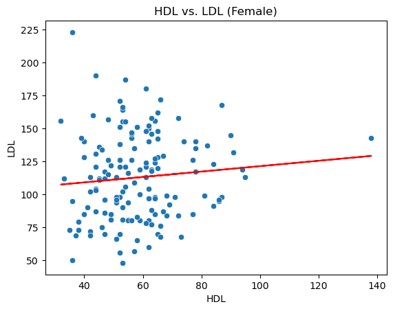

```
Gender: Male
Correlation coefficient: 0.0947, P-value: 0.2441
                            OLS Regression Results
==============================================================================
Dep. Variable:                    LDL   R-squared:                       0.009
Model:                            OLS   Adj. R-squared:                  0.002
Method:                 Least Squares   F-statistic:                     1.367
Date:                Mon, 08 Jul 2024   Prob (F-statistic):              0.244
Time:                        15:10:40   Log-Likelihood:                -769.93
No. Observations:                 153   AIC:                             1544.
Df Residuals:                     151   BIC:                             1550.
Df Model:                           1
Covariance Type:            nonrobust
==============================================================================
                 coef    std err          t      P>|t|      [0.025      0.975]
------------------------------------------------------------------------------
const        102.5792     10.673      9.611      0.000      81.492     123.666
HDL            0.2436      0.208      1.169      0.244      -0.168       0.655
==============================================================================
Omnibus:                        5.458   Durbin-Watson:                   2.219
Prob(Omnibus):                  0.065   Jarque-Bera (JB):                5.174
Skew:                           0.446   Prob(JB):                       0.0752
Kurtosis:                       3.128   Cond. No.                         181.
==============================================================================

Notes:
[1] Standard Errors assume that the covariance matrix of the errors is correctly specified.
Regression line equation: LDL = 102.5792 + 0.2436 * HDL
```

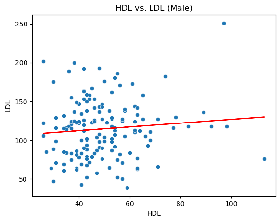

```python
from scipy.stats import pearsonr

hdl = df['HDL']
ldl = df['LDL']

# Calculate correlation coefficient
correlation, p_value = pearsonr(hdl, ldl)
print(f"Correlation coefficient: {correlation:.4f}, P-value: {p_value:.4f}")

# Perform linear regression
X = sm.add_constant(hdl)
model = sm.OLS(ldl, X).fit()
print(model.summary())

# Regression line equation
intercept, slope = model.params
print(f"Regression line equation: LDL = {intercept:.4f} + {slope:.4f} * HDL")

# Plot the data and the regression line
sns.scatterplot(x=hdl, y=ldl)
plt.plot(hdl, intercept + slope * hdl, color='red')
plt.xlabel('HDL')
plt.ylabel('LDL')
plt.title('HDL vs. LDL')
plt.show()

# Separate data by gender
for gender in [0, 1]:
    gender_df = df[df['GENDER (1=M)'] == gender]
    hdl_gender = gender_df['HDL']
    ldl_gender = gender_df['LDL']

    # Calculate correlation coefficient
    correlation_gender, p_value_gender = pearsonr(hdl_gender, ldl_gender)
    print(f"\nGender: {'Female' if gender == 0 else 'Male'}")
    print(f"Correlation coefficient: {correlation_gender:.4f}, P-value: {p_value_gender:.4f}")

    # Perform linear regression
    X_gender = sm.add_constant(hdl_gender)  # Add a constant term to the predictor
    model_gender = sm.OLS(ldl_gender, X_gender).fit()
    print(model_gender.summary())

    # Regression line equation
    intercept_gender, slope_gender = model_gender.params
    print(f"Regression line equation: LDL = {intercept_gender:.4f} + {slope_gender:.4f} * HDL")

    # Plot the data and the regression line
    sns.scatterplot(x=hdl_gender, y=ldl_gender)
    plt.plot(hdl_gender, intercept_gender + slope_gender * hdl_gender, color='red')
    plt.xlabel('HDL')
    plt.ylabel('LDL')
    plt.title(f'HDL vs. LDL ({ "Female" if gender == 0 else "Male"})')
    plt.show()
```

### Exercise 21

Given the pulse rates in Data Set 1 “Body Data”, use two-way analysis of variance to test for an interaction effect, an effect from the row factor of age bracket, and an effect from the column factor of gender. Use a 0.05 significance level.

```
                                sum_sq     df          F    PR(>F)
C(age_bracket)             2724.821546    5.0   4.053619  0.001430
C(gender)                  1903.902390    1.0  14.161835  0.000203
C(age_bracket):C(gender)   1045.740945    5.0   1.555711  0.172648
Residual                  38718.421369  288.0        NaN       NaN
```

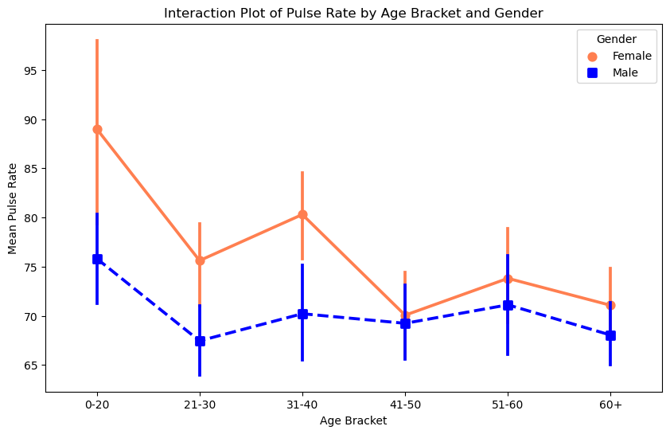

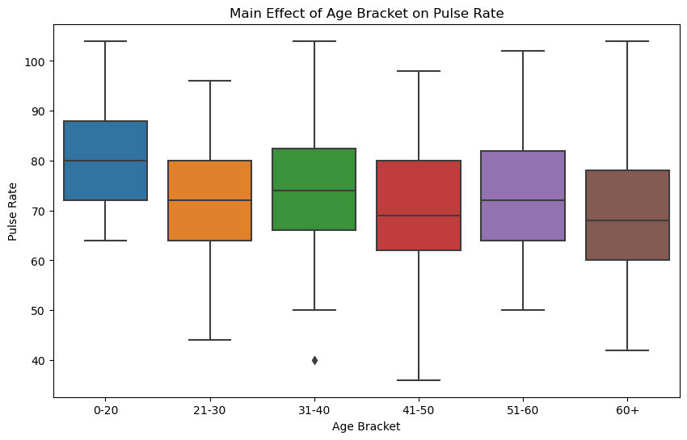

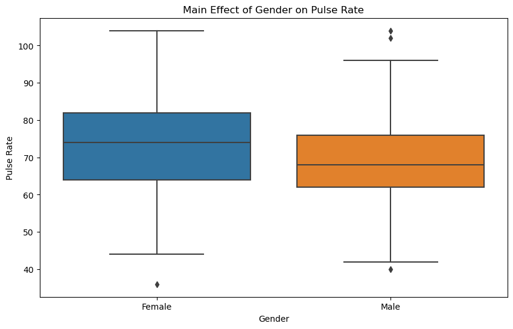

```python
from statsmodels.formula.api import ols
import statsmodels.stats.anova as anova

data = df[['AGE', 'GENDER (1=M)', 'PULSE']].dropna()
data.columns = ['age', 'gender', 'pulse']

# Age brackets
bins = [0, 20, 30, 40, 50, 60, 100]
labels = ['0-20', '21-30', '31-40', '41-50', '51-60', '60+']
data['age_bracket'] = pd.cut(data['age'], bins=bins, labels=labels, right=False)

# Create the model formula
formula = 'pulse ~ C(age_bracket) + C(gender) + C(age_bracket):C(gender)'

# Fit the model
model = ols(formula, data=data).fit()

# ANOVA
anova_table = anova.anova_lm(model, typ=2)

# ANOVA table
print(anova_table)

# Interaction plot
plt.figure(figsize=(10, 6))
ax=sns.pointplot(x='age_bracket', y='pulse', hue='gender', data=data, markers=["o", "s"], linestyles=["-", "--"],
              palette={0: 'coral', 1: 'blue'})
plt.title('Interaction Plot of Pulse Rate by Age Bracket and Gender')
plt.xlabel('Age Bracket')
plt.ylabel('Mean Pulse Rate')
handles, labels = ax.get_legend_handles_labels()
labels = ['Female', 'Male']
plt.legend(handles, labels, title='Gender')
plt.show()

# Main effect plots
# Age Effect
plt.figure(figsize=(10, 6))
sns.boxplot(x='age_bracket', y='pulse', data=data)
plt.title('Main Effect of Age Bracket on Pulse Rate')
plt.xlabel('Age Bracket')
plt.ylabel('Pulse Rate')
plt.show()

# Gender Effect
plt.figure(figsize=(10, 6))
sns.boxplot(x='gender', y='pulse', data=data)
plt.title('Main Effect of Gender on Pulse Rate')
plt.xlabel('Gender')
plt.ylabel('Pulse Rate')
plt.xticks([0, 1], ['Female', 'Male'])
plt.show()
```

### Exercise 22

Does Weight Change with Age? Refer to Data Set 1 “Body Data” and use the weights of males partitioned into the three different age brackets of 18–25, 26–40, and 41–80. Use the methods of this chapter to test the claim that men in those three age brackets have the same mean weight. Sorting One challenge in this project is identifying the weights of men in the three age brackets. First, use the sort feature of your technology to sort all of the columns using Gender as the basis for sorting. You can then delete all of the rows representing females. Then sort all of the columns using Age as the basis for sorting. It will then be much easier to identify the weights in the different age brackets

```
     AGE  WEIGHT age_bracket
290   18    71.6         NaN
12    18   122.7         NaN
65    18    71.7         NaN
287   18    54.1         NaN
41    18    81.3         NaN
                      sum_sq     df         F    PR(>F)
C(age_bracket)    463.335363    2.0  0.756271  0.471269
Residual        44111.392937  144.0       NaN       NaN
```

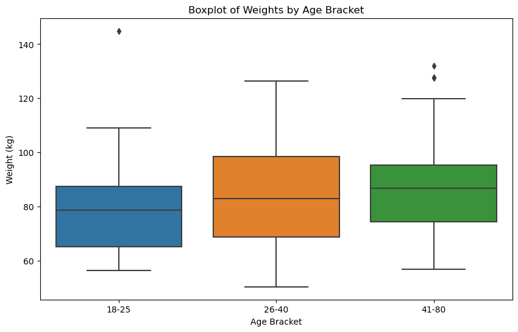

```
             Count       Mean    Std Dev
age_bracket
18-25           15  81.526667  22.763896
26-40           42  84.495238  18.841340
41-80           90  86.952222  15.829791
```

```python
df_sorted_gender = df.sort_values(by='GENDER (1=M)')
df_males = df_sorted_gender[df_sorted_gender['GENDER (1=M)'] == 1]

# Sort by Age
df_males_sorted_age = df_males.sort_values(by='AGE')

# Age brackets
bins = [18, 25, 40, 80]
labels = ['18-25', '26-40', '41-80']
df_males_sorted_age['age_bracket'] = pd.cut(df_males_sorted_age['AGE'], bins=bins, labels=labels, right=True)

print(df_males_sorted_age[['AGE', 'WEIGHT', 'age_bracket']].head())

# ANOVA
formula = 'WEIGHT ~ C(age_bracket)'
model = ols(formula, data=df_males_sorted_age).fit()
anova_table = anova.anova_lm(model, typ=2)

# ANOVA table
print(anova_table)

# Plot the results
plt.figure(figsize=(10, 6))
sns.boxplot(x='age_bracket', y='WEIGHT', data=df_males_sorted_age)
plt.title('Boxplot of Weights by Age Bracket')
plt.xlabel('Age Bracket')
plt.ylabel('Weight (kg)')
plt.show()

# Displaying means and standard deviations
means = df_males_sorted_age.groupby('age_bracket')['WEIGHT'].mean()
std_devs = df_males_sorted_age.groupby('age_bracket')['WEIGHT'].std()
count = df_males_sorted_age.groupby('age_bracket')['WEIGHT'].count()
summary_table = pd.DataFrame({'Count': count, 'Mean': means, 'Std Dev': std_devs})
print(summary_table)
```

### Exercise 23

Refer to the measured systolic and diastolic blood pressure measurements of 153 randomly selected males in Data Set 1 “Body Data” in Appendix B and use a 0.05 significance level to test the claim that among men, there is a correlation between systolic blood pressure and diastolic blood pressure.

```
Pearson correlation coefficient: 0.386
P-value: 0.000
Reject the null hypothesis. There is a significant correlation between systolic and diastolic blood pressure.
```

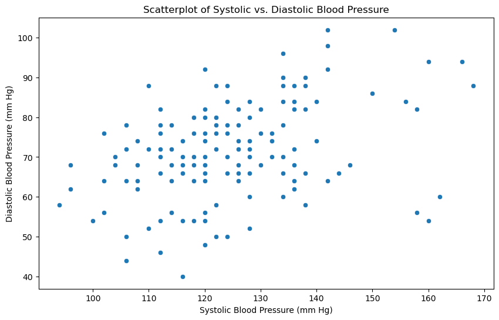

```python
df_males = df[df['GENDER (1=M)'] == 1]

systolic_bp = df_males['SYSTOLIC'].dropna()
diastolic_bp = df_males['DIASTOLIC'].dropna()

# Pearson correlation coefficient and p-value
correlation, p_value = stats.pearsonr(systolic_bp, diastolic_bp)

# Results
print(f"Pearson correlation coefficient: {correlation:.3f}")
print(f"P-value: {p_value:.3f}")
a = 0.05 # significance level
if p_value < a:
    print("Reject the null hypothesis. There is a significant correlation between systolic and diastolic blood pressure.")
else:
    print("Fail to reject the null hypothesis. There is no significant correlation between systolic and diastolic blood pressure.")

# Plot
plt.figure(figsize=(10, 6))
sns.scatterplot(x=systolic_bp, y=diastolic_bp)
plt.title('Scatterplot of Systolic vs. Diastolic Blood Pressure')
plt.xlabel('Systolic Blood Pressure (mm Hg)')
plt.ylabel('Diastolic Blood Pressure (mm Hg)')
plt.show()
```

```python
os.system('jupyter nbconvert --to html --no-input Homework.ipynb --log-level=CRITICAL')
```

```
0
```